# Analysis of Phage Display Protease and Supernatant Screens

# Motif Analysis of Substrate Peptides from Mixtures

To analyze distinct patterns of proteolytic activity, the significantly cleaved peptides of supernatant mixtures were assessed with dimensionalty reduction techniques PCA and UMAP. Peptides were mapped by each position based on 4 amino acid characteristics (charge, disorder, hpath, and relative molecular weight).

PCA/UMAP was followed by K-Means clustering, with the average silouette width used to estimate the optimal number of clusters.

Defining Amino Acid Characteristics

```r
AAreference <- data.frame(
  row.names = c("A", "C", "D", "E", "F", "G", "H", "I", "K", "L", "M", "N", "P", "Q", "R", "S", "T", "V", "W", "Y", "X", "-"),
  CHRG = c(0, 0, -1, -1, 0, 0, 0, 0, 1, 0, 0, 0, 0, 0, 1, 0, 0, 0, 0, 0, NA, NA),
  DISORD = c(0.0600, 0.0200, 0.1920, 0.7360, -0.6970, 0.1660, 0.3030, -0.4860, 0.5860, -0.3260, -0.3970, 0.0070, 0.9870, 0.3180, 0.1800, 0.3410, 0.0590, -0.1210, -0.8840, -0.5100, NA, NA),
  HPATH = c(1.80, 2.50, -3.50, -3.50, 2.80, -0.40, -3.20, 4.50, -3.90, 3.80, 1.90, -3.50,  -1.60, -3.50, -4.50, -0.80, -0.70, 4.20, -0.90, -1.30, NA, NA),
  RMW = c(15.090, 47.160, 59.100, 73.130, 91.190, 1.070, 81.160, 57.180, 72.190, 57.180, 75.210, 58.120, 41.130, 72.150, 100.200, 31.090, 45.120, 43.150, 130.230, 107.190, NA, NA),
  NOTGAP = c(1, 1, 1, 1, 1, 1, 1, 1, 1, 1, 1, 1, 1, 1, 1, 1, 1, 1, 1, 1, 1, 0))
properties_df <- as.data.frame(AAreference)[, -ncol(AAreference)]
```

The subsequent code, from dataframe generation to ggseqlogo creation, was repeated for each of the 4 mixture conditions with different inhibitors.

## Generation of Input Dataframe

A 20 column dataframe, of 4 amino acid properties across 5 positions for each peptide, was generated. This was normalized based on columns and used as input for PCA and UMAP.

```r
i = 5 #i = 5-8 for mixtures
peptides = peptideList[i]

features_df <- data.frame(matrix(nrow = length(peptides), ncol = nchar(peptides[[1]][1])*ncol(properties_df)))
colnames(features_df) <- rep(paste0(colnames(properties_df), rep(1:nchar(peptides[[1]][1]), each = ncol(properties_df))), length(peptides))
for (k in 1:length(peptides[[1]])) {
  rows <- data.frame(col1 = NA)
  for (j in 1:nchar(peptides[[1]][1])){
    amino_acid <- substr(peptides[[1]][k], j, j)
    rows_with <- properties_df[rownames(properties_df) == amino_acid, ]
    rows <- cbind(rows, rows_with)
  }
  rows <- rows[,-1]
  colnames(rows) <- rep(paste0(colnames(properties_df), rep(1:nchar(peptides[[1]][1]), each = ncol(properties_df))), length(peptides))
  rownames(rows) <- c(peptides[[1]][k])
  features_df <- rbind(features_df, rows)
}
features_df <- features_df[-1, ]
df.n <- clusterSim::data.Normalization(features_df, type="n1", normalization="column")
```

## PCA Analysis

After silhouette Width analysis, the number of clusters for K-means clustering was adjusted. An example plot of cleaved peptides by the supernatant without inhibitors was presented, with all plots in the supplemental figures.

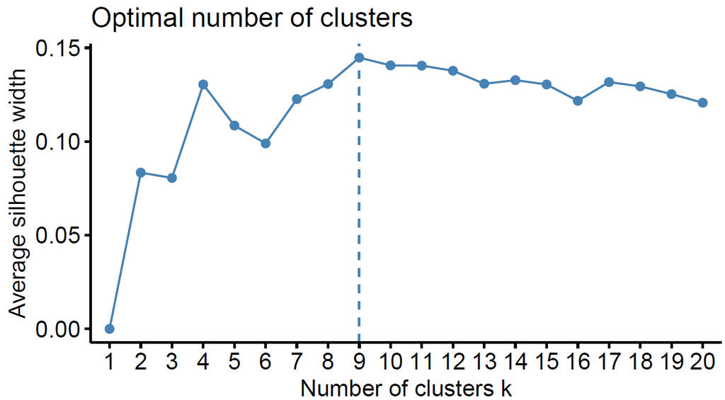

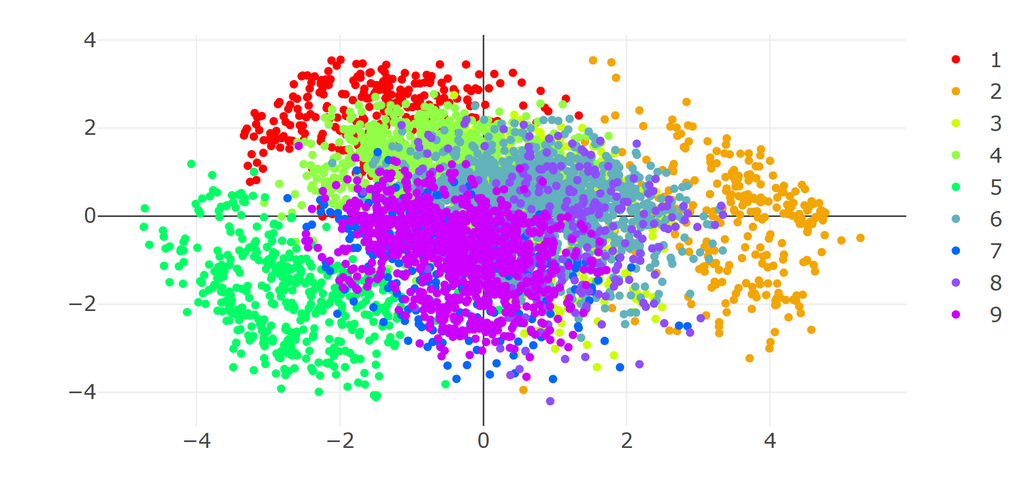

PCA Visualization of significantly cleaved peptides by the supernatant of activated neutrophils

```r
pca_result <- prcomp(df.n, scale. = TRUE)
fviz_nbclust(pca_result$x, FUNcluster=kmeans, k.max = 20, method = "silhouette")
kmeans_result <- kmeans(pca_result$x, centers = 9) #number of centrers adjusted based on the peak average silhouette width
df.n$PCACluster <- kmeans_result$cluster
pca_result$cluster <- as.factor(kmeans_result$cluster)

plot_pca <- plot_ly(x = pca_result$x[,1], y = pca_result$x[,2], type = 'scatter', mode = 'markers',color = pca_result$cluster, colors = rainbow(5), marker = list(size = 5))
plot_pca
```

## UMAP Analysis

The prior analysis was repeated for UMAP. All plots were placed in the supplemental figures.

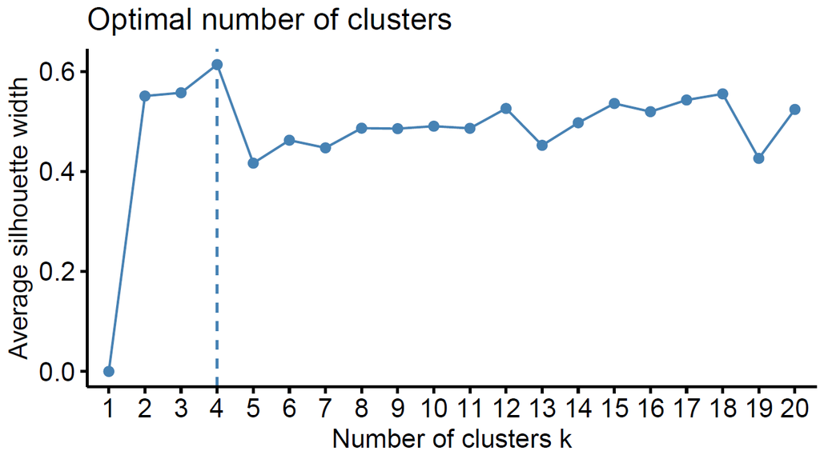

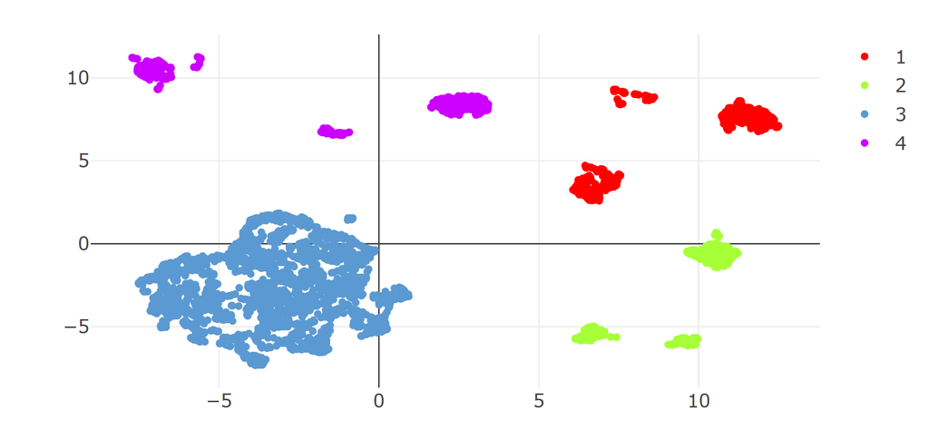

UMAP Visualization of Significantly Cleaved Peptides by the supernatant of activated neutrophils

```r
umap_result <- umap(df.n, scale = TRUE)
fviz_nbclust(umap_result$layout, FUNcluster=kmeans, k.max = 20, method = "silhouette")
kmeans_result <- kmeans(umap_result$layout, centers = 4) #number of centrers adjusted based on the peak average silhouette width
df.n$UMAPCluster <- kmeans_result$cluster
umap_result$cluster <- as.factor(kmeans_result$cluster)

plot_umap <- plot_ly(x = umap_result$layout[,1], y = umap_result$layout[,2], type = 'scatter', mode = 'markers',color = umap_result$cluster, colors = rainbow(5), marker = list(size = 5))
plot_umap
```

## Assessing Motif Logos

The sequence logos for each cluster from PCA and UMAP analysis were generated

```r
temp <- df.n
temp$Peptide <- row.names(df.n)
PCAclusters <- split(temp$Peptide, temp$PCACluster)
names(PCAclusters) <- sapply(1:length(PCAclusters), function(i) {
  paste0(names(PCAclusters)[i], " (", length(PCAclusters[[i]]), ")")
})

PCApeptides <- unlist(PCAclusters)
clustercol <- sub("\\s.*", "", rep(names(PCAclusters), lengths(PCAclusters)))
PCAdf <- data.frame(Peptide = PCApeptides, Cluster = clustercol)
write.table(PCAdf, file = paste0(combined[i],"_PCAclusters.txt"), sep = "\t", row.names = FALSE, quote = FALSE)
```

```r
temp <- df.n
temp$Peptide <- row.names(df.n)
UMAPclusters <- split(temp$Peptide, temp$UMAPCluster)
names(UMAPclusters) <- sapply(1:length(UMAPclusters), function(i) {
  paste0(names(UMAPclusters)[i], " (", length(UMAPclusters[[i]]), ")")
})

UMAPpeptides <- unlist(UMAPclusters)
clustercol <- sub("\\s.*", "", rep(names(UMAPclusters), lengths(UMAPclusters)))
UMAPdf <- data.frame(Peptide = UMAPpeptides, Cluster = clustercol)
write.table(UMAPdf, file = paste0(combined[i],"_UMAPclusters.txt"), sep = "\t", row.names = FALSE, quote = FALSE)
```

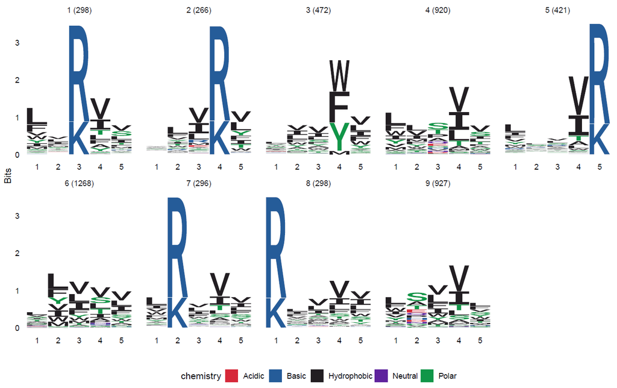

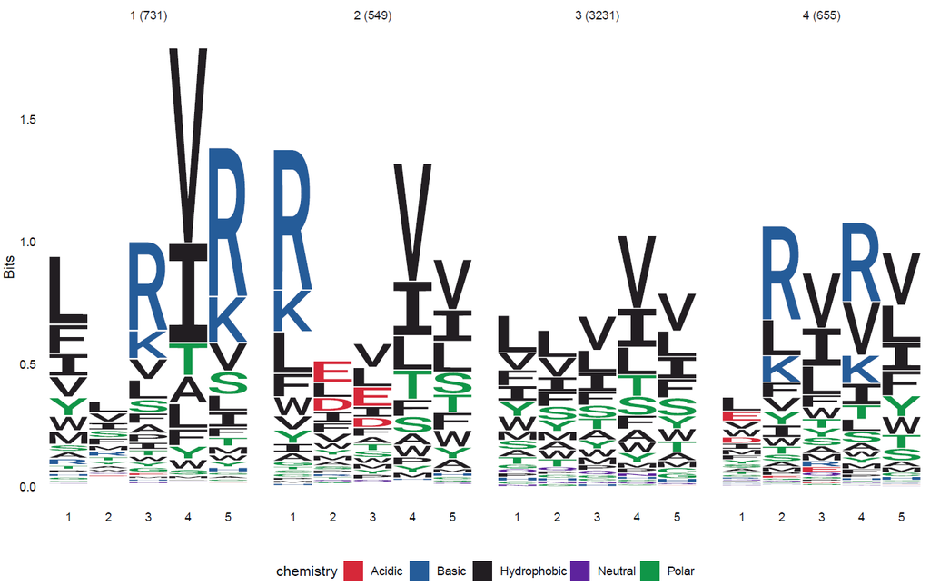

Clustered Motifs of Significantly Cleaved Peptides by the supernatant, from PCA (Left) and UMAP (Right) with K-means clustering

```r
ggseqlogo(PCAclusters, ncol = 5)
ggseqlogo(UMAPclusters, ncol = 5)
```

## Analysis between Proteases

In an attempt to detect individual protease signatures within the complex mixture sample, dimensionalty reduction of PCA/UMAP was applied on the substrates of two sources, 1) pooled cleaved peptides of all three serine proteases, and 2) the mixture supernatant. Peptides from each of the three proteases were labelled by color.

### Pooled Peptides of All Serine Proteases

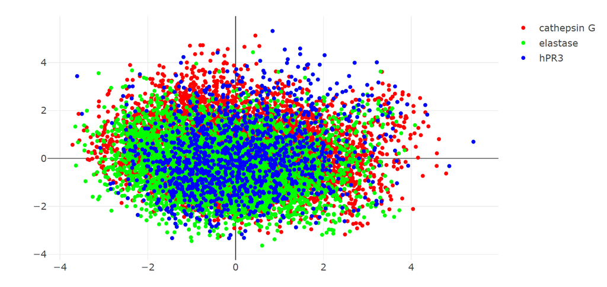

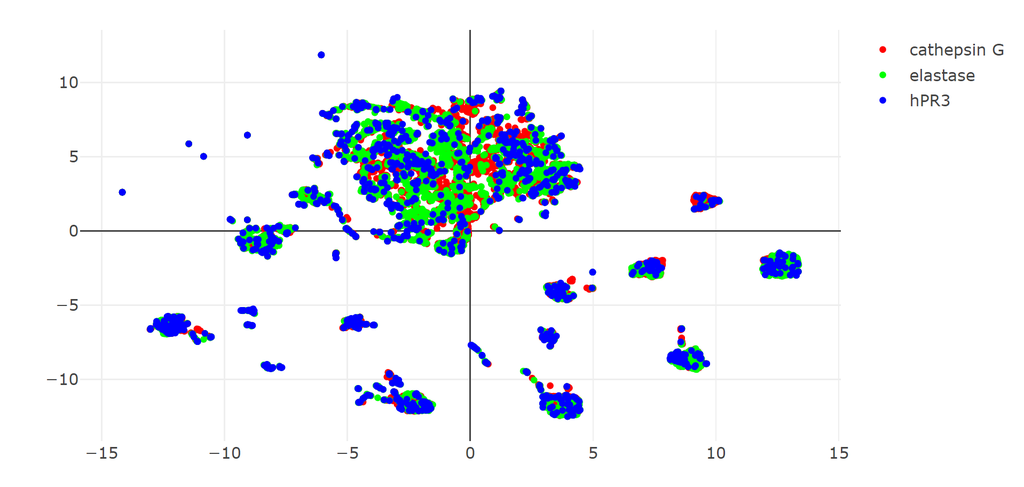

```r
df <- enframe(peptideList[1:3], name = "protease", value = "peptide") %>%
  unnest_longer(peptide)
features_df <- data.frame(matrix(nrow = 1, ncol = 5*ncol(properties_df)))
colnames(features_df) <- rep(paste0(colnames(properties_df), rep(1:5, each = ncol(properties_df))), 1)

for (k in 1:nrow(df)) {
  rows <- data.frame(col1 = NA)
  for (j in 1:5){
    amino_acid <- substr(df[k,2], j, j)
    rows_with <- properties_df[rownames(properties_df) == amino_acid, ]
    rows <- cbind(rows, rows_with)
  }
  rows <- rows[,-1]
  colnames(rows) <- rep(paste0(colnames(properties_df), rep(1:5, each = ncol(properties_df))), 1)
  rownames(rows) <- c(df[k,2])
  features_df <- rbind(features_df, rows)
}
features_df <- features_df[-1, ]
df.n <- clusterSim::data.Normalization(features_df, type="n1", normalization="column")
df.n <- bind_cols(df.n, df$protease)
colnames(df.n)[ncol(df.n)] <- "protease"

pca_result <- prcomp(df.n[-ncol(df.n)], scale. = TRUE)
umap_result <- umap(df.n[-ncol(df.n)], scale = TRUE)

plot_pca <- plot_ly(x = pca_result$x[,1], y = pca_result$x[,2], type = 'scatter', mode = 'markers',color = df.n$protease, colors = rainbow(3), marker = list(size = 5))
plot_pca
plot_umap <- plot_ly(x = umap_result$layout[,1], y = umap_result$layout[,2], type = 'scatter', mode = 'markers',color = df.n$protease, colors = rainbow(3), marker = list(size = 5))
plot_umap
```

### Serine Proteases within Cleaved Peptides by Neutrophil Supernatant

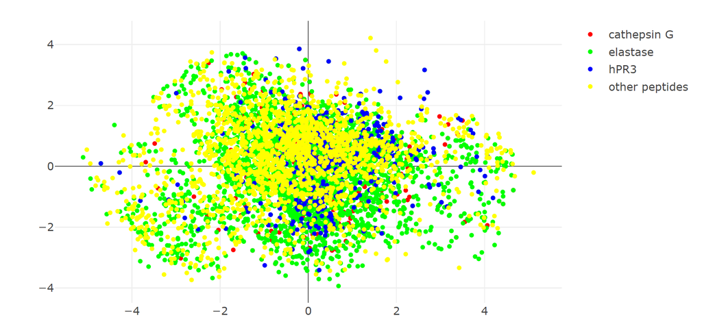

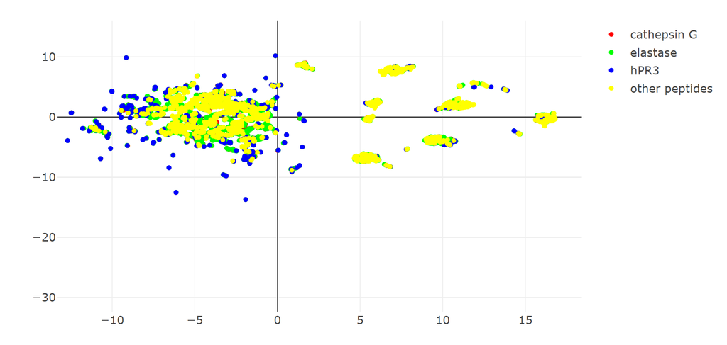

```r
cathepsinG_peptides <- intersect(peptides, peptideList[[1]])
elastase_peptides <- intersect(peptides, peptideList[[2]])
hPR3_peptides <- intersect(peptides, peptideList[[3]])
other_peptides <- setdiff(peptides, union(peptideList[[1]], union(peptideList[[2]], peptideList[[3]])))
mixture_list <- list(cathepsinG_peptides, elastase_peptides, hPR3_peptides, other_peptides)
names(mixture_list) <- c("cathepsin G", "elastase", "hPR3", "other peptides")
df <- enframe(mixture_list, name = "protease", value = "peptide") %>%
  unnest_longer(peptide)

features_df <- data.frame(matrix(nrow = 1, ncol = 5*ncol(properties_df)))
colnames(features_df) <- rep(paste0(colnames(properties_df), rep(1:5, each = ncol(properties_df))), 1)

for (k in 1:nrow(df)) {
  rows <- data.frame(col1 = NA)
  for (j in 1:5){
    amino_acid <- substr(df[k,2], j, j)
    rows_with <- properties_df[rownames(properties_df) == amino_acid, ]
    rows <- cbind(rows, rows_with)
  }
  rows <- rows[,-1]
  colnames(rows) <- rep(paste0(colnames(properties_df), rep(1:5, each = ncol(properties_df))), 1)
  rownames(rows) <- c(df[k,2])
  features_df <- rbind(features_df, rows)
}
features_df <- features_df[-1, ]
df.n <- clusterSim::data.Normalization(features_df, type="n1", normalization="column")
df.n <- bind_cols(df.n, df$protease)
colnames(df.n)[ncol(df.n)] <- "protease"

pca_result <- prcomp(df.n[-ncol(df.n)], scale. = TRUE)
umap_result <- umap(df.n[-ncol(df.n)], scale = TRUE)

plot_pca <- plot_ly(x = pca_result$x[,1], y = pca_result$x[,2], type = 'scatter', mode = 'markers',color = df.n$protease, colors = c("red", "green", "blue", 'yellow'), marker = list(size = 5))
plot_pca
plot_umap <- plot_ly(x = umap_result$layout[,1], y = umap_result$layout[,2], type = 'scatter', mode = 'markers',color = df.n$protease, colors = c("red", "green", "blue", 'yellow'), marker = list(size = 5))
plot_umap
```